# Analysis of Effect of Alcohol on Grades of Math and Portugese Language Course

## Questions

How does the overall data looks like? Is it skewed? How is correlation looking between attributes of dataframe? Compare how students grades vary based on the alcohol consumption? How can we predict final grades of students using features that describe students personal and social situations?

## Hypothesis

We predict that alcohol will have a negative effect on the student’s math and portugese langauge grades. Additionally, we also predict that the number of absences and the amount a student goes out will have a direct correlation with a student’s grade.

## Motivation

As alcohol becomes more accessible to students around the world due to fake IDs and other forms of fraud, the impact of alcohol consumption on kids’ schooling grows. One of the goals is to spread awareness about consequences of drinking alcholol among teenagers which will help take responsible decisions. In addition, as the world opens up to drinking as a form of a social activity, it is interesting to see whether that opens up alcohol to students as well.

## Description of Data

The data was collected in secondary schools in Portugal for students ages 15-19 in their Math and Portuguese language classes. The dataset has attributes that consider the student’s upbringing through information such as parent’s job, parent’s cohabitation status, and parent’s education level as well as family size. The data collected tries to create a full picture of the environment in which these students live in and which environments produce positive results in terms of better grades and reduced alcohol consumption. The dataset also considers the social life of students and their socio-economic status and their previous academic performance as attributes to create this bigger picture of who the students are.

## Biases/Assumptions/Rationale:

There are societal assumptions that alcohol is a substance that negatively impacts education and success. There is also the assumption that weekend alcohol consumption is considered more socially acceptable and this is an attribute that the dataset acknowledges. There are also assumptions that the students that go out more, are going out in an environment likely with alcoholic substances, but going out with friends does not necessarily equate to a time to consume alcohol. There is also a bias that students whose parents do not have much education or high-paying jobs or student’s that do not live in a traditional family context are more likely to get bad grades which is not always the case.

## Data Content

Attributes meaning for 'student-mat.csv' and 'student-por.csv' datasets

1. **school** - student's school name ('MS' - Mousinho da Silveira or 'GP' - Gabriel Pereira)
2. **sex** - student's sex ('F' - Female or 'M' - Male)
3. **age** - student's age (from 15 to 22)
4. **address** - student's home address type ('U' - Urban or 'R' - Rural)
5. **famsize** - family size ('LE3' - Less or equal to 3 or 'GT3' - Greater than 3)
6. **Pstatus** - parent's cohabitation status ('T' - Living Together or 'A' - apart)
7. **Medu** - mother's education (0 - none, 1 - primary education (4th grade), 2 - 5th to 9th grade, 3 - secondary education or 4 - higher education)
8. **Fedu** - father's education (0 - none, 1 - primary education (4th grade), 2 - 5th to 9th grade, 3 - secondary education or 4 - higher education)
9. **Mjob** - mother's job (nominal: 'teacher', 'health' care related, civil 'services'(e.g. administrative or police), 'at_home' or 'other')
10. **Fjob** - mother's job (nominal: 'teacher', 'health' care related, civil 'services'(e.g. administrative or police), 'at_home' or 'other')
11. **reason** - reason to choose this school (nominal: close to 'home', school 'reputation', 'course' preference or 'other')
12. **guardian** - student's guardian (nominal: 'mother', 'father' or 'other')
13. **traveltime** - home to school travel time (1 - <15 min., 2 - 15 to 30 min., 3 - 30 min. to 1 hour, or 4 - >1 hour)
14. **studytime** - weekly study time (1 - <2 hours, 2 - 2 to 5 hours, 3 - 5 to 10 hours, or 4 - >10 hours)
15. **failures** - number of past class failures (n if 1<=n<3, else 4)
16. **schoolsup** - extra educational support (yes or no)
17. **famsup** - family educational support (yes or no)
18. **paid** - extra paid classes within the course subject (Math or Portuguese) (yes or no)
19. **activities** - extra-curricular activities (yes or no)
20. **nursery** - attended nursery school (yes or no)
21. **higher** - wants to take higher education (yes or no)
22. **internet** - Internet access at home (yes or no)
23. **romantic** - with a romantic relationship (yes or no)
24. **famrel** - quality of family relationships (from 1 - very bad to 5 - excellent)
25. **freetime** - free time after school (from 1 - very low to 5 - very high)
26. **goout** - going out with friends (from 1 - very low to 5 - very high)
27. **Dalc** - workday alcohol consumption (from 1 - very low to 5 - very high)
28. **Walc** - weekend alcohol consumption (from 1 - very low to 5 - very high)
29. **health** - current health status (from 1 - very bad to 5 - very good)
30. **absences** - number of school absences (from 0 to 93)
31. **G1** - first period grade (from 0 to 20)
32. **G2** - second period grade (from 0 to 20)
33. **G3** - final grade (from 0 to 20)

```python
import pandas as pd
import numpy as np
import seaborn as sns
import matplotlib
import matplotlib.pyplot as plt
from sklearn import metrics
from sklearn.tree import DecisionTreeClassifier
from sklearn.ensemble import RandomForestClassifier
from sklearn.svm import SVC
from sklearn.ensemble import GradientBoostingClassifier
from sklearn.ensemble import AdaBoostClassifier
from sklearn.model_selection import train_test_split
from sklearn.metrics import classification_report, confusion_matrix
#%matplotlib inline
studentMAT = pd.read_csv("student-mat.csv")
studentPOR = pd.read_csv("student-por.csv")
studentPOR
```

|  | school | sex | age | address | famsize | Pstatus | Medu | Fedu | Mjob | Fjob | ... | famrel | freetime | goout | Dalc | Walc | health | absences | G1 | G2 | G3 |
| --- | --- | --- | --- | --- | --- | --- | --- | --- | --- | --- | --- | --- | --- | --- | --- | --- | --- | --- | --- | --- | --- |
| 0 | GP | F | 18 | U | GT3 | A | 4 | 4 | at_home | teacher | ... | 4 | 3 | 4 | 1 | 1 | 3 | 4 | 0 | 11 | 11 |
| 1 | GP | F | 17 | U | GT3 | T | 1 | 1 | at_home | other | ... | 5 | 3 | 3 | 1 | 1 | 3 | 2 | 9 | 11 | 11 |
| 2 | GP | F | 15 | U | LE3 | T | 1 | 1 | at_home | other | ... | 4 | 3 | 2 | 2 | 3 | 3 | 6 | 12 | 13 | 12 |
| 3 | GP | F | 15 | U | GT3 | T | 4 | 2 | health | services | ... | 3 | 2 | 2 | 1 | 1 | 5 | 0 | 14 | 14 | 14 |
| 4 | GP | F | 16 | U | GT3 | T | 3 | 3 | other | other | ... | 4 | 3 | 2 | 1 | 2 | 5 | 0 | 11 | 13 | 13 |
| ... | ... | ... | ... | ... | ... | ... | ... | ... | ... | ... | ... | ... | ... | ... | ... | ... | ... | ... | ... | ... | ... |
| 644 | MS | F | 19 | R | GT3 | T | 2 | 3 | services | other | ... | 5 | 4 | 2 | 1 | 2 | 5 | 4 | 10 | 11 | 10 |
| 645 | MS | F | 18 | U | LE3 | T | 3 | 1 | teacher | services | ... | 4 | 3 | 4 | 1 | 1 | 1 | 4 | 15 | 15 | 16 |
| 646 | MS | F | 18 | U | GT3 | T | 1 | 1 | other | other | ... | 1 | 1 | 1 | 1 | 1 | 5 | 6 | 11 | 12 | 9 |
| 647 | MS | M | 17 | U | LE3 | T | 3 | 1 | services | services | ... | 2 | 4 | 5 | 3 | 4 | 2 | 6 | 10 | 10 | 10 |
| 648 | MS | M | 18 | R | LE3 | T | 3 | 2 | services | other | ... | 4 | 4 | 1 | 3 | 4 | 5 | 4 | 10 | 11 | 11 |

649 rows × 33 columns

Before we begin to address question, we want to see if the data is skewed and make some observations based on the overall data.

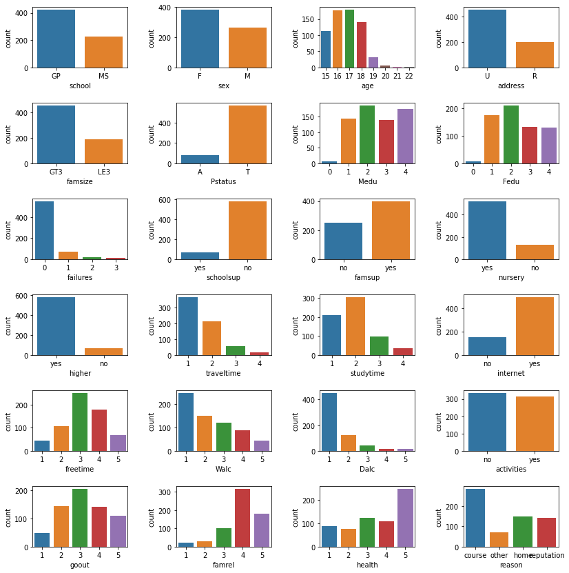

```python
fig, axes = plt.subplots(6, 4, figsize = (12, 12))
fig.tight_layout(pad = 3)

ax1 = plt.subplot(axes[0, 0])
ax1 = sns.countplot(data = studentPOR, x = studentPOR['school'])
ax2 = plt.subplot(axes[0, 1])
ax2 = sns.countplot(data = studentPOR, x = studentPOR['sex'])
ax3 = plt.subplot(axes[0, 2])
ax3 = sns.countplot(data = studentPOR, x = studentPOR['age'])
ax4 = plt.subplot(axes[0, 3])
ax4 = sns.countplot(data = studentPOR, x = studentPOR['address'])
ax5 = plt.subplot(axes[1, 0])
ax5 = sns.countplot(data = studentPOR, x = studentPOR['famsize'])
ax6 = plt.subplot(axes[1, 1])
ax6 = sns.countplot(data = studentPOR, x = studentPOR['Pstatus'])
ax7 = plt.subplot(axes[1, 2])
ax7 = sns.countplot(data = studentPOR, x = studentPOR['Medu'])
ax8 = plt.subplot(axes[1, 3])
ax8 = sns.countplot(data = studentPOR, x = studentPOR['Fedu'])
ax9 = plt.subplot(axes[2, 0])
ax9 = sns.countplot(data = studentPOR, x = studentPOR['failures'])
ax10 = plt.subplot(axes[2, 1])
ax10 = sns.countplot(data = studentPOR, x = studentPOR['schoolsup'])
ax11 = plt.subplot(axes[2, 2])
ax11 = sns.countplot(data = studentPOR, x = studentPOR['famsup'])
ax12 = plt.subplot(axes[2, 3])
ax12 = sns.countplot(data = studentPOR, x = studentPOR['nursery'])
ax13 = plt.subplot(axes[3, 0])
ax13 = sns.countplot(data = studentPOR, x = studentPOR['higher'])
ax14 = plt.subplot(axes[3, 1])
ax14 = sns.countplot(data = studentPOR, x = studentPOR['traveltime'])
ax15 = plt.subplot(axes[3, 2])
ax15 = sns.countplot(data = studentPOR, x = studentPOR['studytime'])
ax16 = plt.subplot(axes[3, 3])
ax16 = sns.countplot(data = studentPOR, x = studentPOR['internet'])
ax17 = plt.subplot(axes[4, 0])
ax17 = sns.countplot(data = studentPOR, x = studentPOR['freetime'])
ax18 = plt.subplot(axes[4, 1])
ax18 = sns.countplot(data = studentPOR, x = studentPOR['Walc'])
ax19 = plt.subplot(axes[4, 2])
ax19 = sns.countplot(data = studentPOR, x = studentPOR['Dalc'])
ax20 = plt.subplot(axes[4, 3])
ax20 = sns.countplot(data = studentPOR, x = studentPOR['activities'])
ax21 = plt.subplot(axes[5, 0])
ax21 = sns.countplot(data = studentPOR, x = studentPOR['goout'])
ax22 = plt.subplot(axes[5, 1])
ax22 = sns.countplot(data = studentPOR, x = studentPOR['famrel'])
ax23 = plt.subplot(axes[5, 2])
ax23 = sns.countplot(data = studentPOR, x = studentPOR['health'])
ax24 = plt.subplot(axes[5, 3])
ax24 = sns.countplot(data = studentPOR, x = studentPOR['reason'])
```

**General observations about the student-por.csv data:**

1. Most of the variables such as school, address, famsize, Pstatus, schoolsup, famsup, nursery, higher, internet, are skewed towards one value over the other, except for the 'activities' variable.
2. There are more females than males.
3. Medu and Fedu have a balanced distribution.
4. There are more than 50% of the students who take less than 15 minutes to reach school, rest of them take about 15 to 30 minutes or more than 30 minutes to reach school.
5. It seems half of the students tend to study 2 to 5 hours per week, nearly 200 of them study less than 2 hours per week, and the rest of them are studying more than 5 hours per week.
6. There are nearly more than approx. 70% students who never failed a course.
7. Half of the students tends to be comfortable with the family.
8. freetime and goout share almost similar distribution.
9. Weekday alcohol consumption is quite minimal.
10. Weekends alcohol consumption increases, while the group of students who consume or consume little alcohol remains dominant.
11. Approx. 40% students are in good health.
12. Many students chose the school due to the course of study, others since it was closer to home, or it's reputation and there are minority who chose it for some other reasons.

To start off answering the questions we can start by observing the correlation amongst the data attributes.

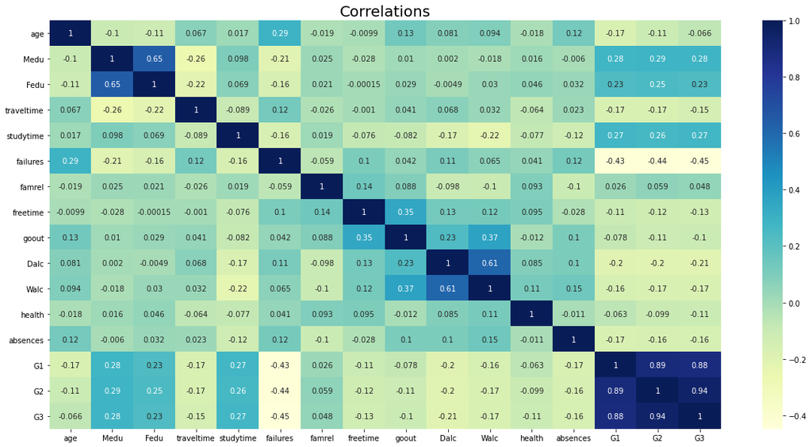

```python
fig = plt.figure(figsize = (20, 10))
sns.heatmap(studentPOR.corr(method = "spearman"), cmap="YlGnBu", annot = True)
plt.title("Correlations", size = 20)
```

**Some Observations from the correlation heatmap graph above:**

*1. There is a strong positive correlation between the 3 grades G1, G2, G3. Meaning if G1 increases, G2 and G3 also increases.*

*2. There is a weak positive correlation between age and absences. Meaning if age increases, absences increases weakly.*

*3. There is also a weak negative correlation between age, absences with respect to grades G1, G2, G3. Meaning if age or absences increases, grades decreases.*

*4. "Medu" and "Fedu" have a strong positive correlation(0.65). As a result it seems like parents tend to have the same level of education.*

*5. "Dalc" and "Walc" have a strong positive correlation(0.61). Meaning high weekday alcohol consumption leads to high weekend alcohol consumption.*

*6. "Walc" is moderately correlated with "goout"(0.37). It can be said that people who go out with their friends tend to drink alcohol.*

*7. "goout" and "freetime" are moderately correlated(0.35). So the number of times a student goes out with friends depends on the amount of free time.*

*8. "Walc" and "study time" have a moderate negative correlation(-0.22). So students who are likely to spend more time studying drink less alcohol on weekends.*

*9. "Medu" and "Fedu" have a moderate negative correlation with "traveltime". Meaning if the parents have a high level of education, the student seems to be located closer to school.*

*10. "Medu" and "Fedu" have a moderate negative correlation with "failures". Meaning if parents have a high level of education, the student tends to fail less in their course.*

*11. "Medu" and Fedu" have a weak correlation with G1, G2, and G3 grades. Meaning if the level of parent's education increases, the student's grades increases.*

*12. "studytime" has a weak positive correlation with grades G1,G2 and G3. Meaning if the hours of study per week increases for students, the students grades are more likely to increase.*

*13. "Failures" is moderately correlated with "age". Meaning older students tend to have more failures than younger students.*

*14. "failures" has a moderate negative correlation with G1, G2, and G3 grades. Meaning a student with higher grades are likely to have fewer failures.*

*15. "Dalc", "Walc", and "traveltime" have a weak negative correlation with grades G1, G2, G3.*

**How consumption of Alcohol is affecting the grades mainly G1, G2, and G3 ?**

We can see the how student's grade vary over the consumption of alcohol in weekdays and weekends using the boxplot.

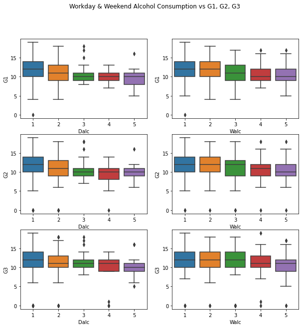

```python
fig, axes = plt.subplots(3, 2, figsize = (10, 10))

ax1 = plt.subplot(axes[0, 0])
ax1 = sns.boxplot(data = studentPOR, x = studentPOR['Dalc'], y = studentPOR['G1'])
ax2 = plt.subplot(axes[0, 1])
ax2 = sns.boxplot(data = studentPOR, x = studentPOR['Walc'], y = studentPOR['G1'])

ax3 = plt.subplot(axes[1, 0])
ax3 = sns.boxplot(data = studentPOR, x = studentPOR['Dalc'], y = studentPOR['G2'])
ax4 = plt.subplot(axes[1, 1])
ax4 = sns.boxplot(data = studentPOR, x = studentPOR['Walc'], y = studentPOR['G2'])

ax5 = plt.subplot(axes[2, 0])
ax5 = sns.boxplot(data = studentPOR, x = studentPOR['Dalc'], y = studentPOR['G3'])
ax6 = plt.subplot(axes[2, 1])
ax6 = sns.boxplot(data = studentPOR, x = studentPOR['Walc'], y = studentPOR['G3'])

plt.suptitle('Workday & Weekend Alcohol Consumption vs G1, G2, G3')
```

**At this point, we can observe from the boxplots above that the grades are less (i.e. G1, G2, & G3) for students with higher consumption of alcohol. As a result, grades tend to be decreasing as the alcohol consumption increases.**

Understanding from the above two sentences, it can be clearly concluded that grades are affected by alcohol consumption and in relate to that weekday alcohol consumption is increased by weekend alcohol consumption and overall consumption of alcohol is likely to happen because students have more time to go out with friends and leading them to drink.

To back up the argument, we can build two seperate dataframes from studentPOR dataframe based on the alcohol consumption but since alcohol consumption is seperated into workday alcohol consumption and weekend alcohol consumption (i.e. 'Dalc', 'Walc'), we can add the values of Walc and Dalc, to calculate the total alcohol consumption. Similarly, we can get total grades by adding G1, G2, and G3. And using these two dataframes we can calculate the mean difference and use it as a part of analysis.

Note, total alcohol consumption will range from 1 - very low to 10 - very high.

Note, total grade will range from 0 to 60.

```python
studentPOR['Total_Alcohol_Consumption'] = studentPOR['Walc'] + studentPOR['Dalc']
studentPOR['Total_Grade'] = studentPOR['G1'] + studentPOR['G2'] + studentPOR['G3']
studentPOR.head()
```

|  | school | sex | age | address | famsize | Pstatus | Medu | Fedu | Mjob | Fjob | ... | goout | Dalc | Walc | health | absences | G1 | G2 | G3 | Total_Alcohol_Consumption | Total_Grade |
| --- | --- | --- | --- | --- | --- | --- | --- | --- | --- | --- | --- | --- | --- | --- | --- | --- | --- | --- | --- | --- | --- |
| 0 | GP | F | 18 | U | GT3 | A | 4 | 4 | at_home | teacher | ... | 4 | 1 | 1 | 3 | 4 | 0 | 11 | 11 | 2 | 22 |
| 1 | GP | F | 17 | U | GT3 | T | 1 | 1 | at_home | other | ... | 3 | 1 | 1 | 3 | 2 | 9 | 11 | 11 | 2 | 31 |
| 2 | GP | F | 15 | U | LE3 | T | 1 | 1 | at_home | other | ... | 2 | 2 | 3 | 3 | 6 | 12 | 13 | 12 | 5 | 37 |
| 3 | GP | F | 15 | U | GT3 | T | 4 | 2 | health | services | ... | 2 | 1 | 1 | 5 | 0 | 14 | 14 | 14 | 2 | 42 |
| 4 | GP | F | 16 | U | GT3 | T | 3 | 3 | other | other | ... | 2 | 1 | 2 | 5 | 0 | 11 | 13 | 13 | 3 | 37 |

5 rows × 35 columns

Since we have calculated total grade and total alcohol consumption of students we want to crate two different dataframes mainly one which has less alcohol consumption and second with high alcohol consumption.

Since the total alcohol consumption ranges from 1 (very low) to 10 (very high), we can use this range in order to create two dataframes. Dataframe with low alcohol consumption will have students whose total alcohol consumption <= 5. Similarly, high alcohol consumption dataframe will consist of students whose total alcohol consumption > 5.

Also we can drop the columns 'G1', 'G2', 'G3', 'Walc', 'Dalc'.

```python
alc_cons_low = studentPOR[studentPOR.Total_Alcohol_Consumption <= 5]
alc_cons_low = alc_cons_low.sort_values(['Total_Alcohol_Consumption'], ascending = False)
alc_cons_low = alc_cons_low.drop(['G1', 'G2', 'G3', 'Walc', 'Dalc'] , axis = 1)
alc_cons_low = alc_cons_low.reset_index(drop = True)
alc_cons_low.head()
```

|  | school | sex | age | address | famsize | Pstatus | Medu | Fedu | Mjob | Fjob | ... | higher | internet | romantic | famrel | freetime | goout | health | absences | Total_Alcohol_Consumption | Total_Grade |
| --- | --- | --- | --- | --- | --- | --- | --- | --- | --- | --- | --- | --- | --- | --- | --- | --- | --- | --- | --- | --- | --- |
| 0 | GP | F | 17 | U | GT3 | T | 4 | 4 | teacher | services | ... | yes | yes | yes | 5 | 3 | 1 | 5 | 2 | 5 | 34 |
| 1 | GP | F | 15 | U | GT3 | T | 1 | 1 | other | other | ... | yes | yes | no | 4 | 3 | 2 | 4 | 2 | 5 | 37 |
| 2 | GP | F | 16 | U | GT3 | T | 2 | 2 | services | other | ... | yes | yes | no | 3 | 4 | 4 | 5 | 0 | 5 | 39 |
| 3 | MS | F | 18 | U | LE3 | T | 2 | 2 | services | services | ... | yes | yes | yes | 5 | 4 | 5 | 3 | 0 | 5 | 36 |
| 4 | GP | F | 16 | U | LE3 | T | 3 | 1 | other | other | ... | yes | no | no | 3 | 3 | 3 | 2 | 0 | 5 | 37 |

5 rows × 30 columns

```python
alc_cons_high = studentPOR[studentPOR.Total_Alcohol_Consumption > 5]
alc_cons_high = alc_cons_high.sort_values(['Total_Alcohol_Consumption'], ascending = False)
alc_cons_high = alc_cons_high.drop(['G1', 'G2', 'G3', 'Walc', 'Dalc'], axis = 1)
alc_cons_high = alc_cons_high.reset_index(drop = True)
alc_cons_high.head()
```

|  | school | sex | age | address | famsize | Pstatus | Medu | Fedu | Mjob | Fjob | ... | higher | internet | romantic | famrel | freetime | goout | health | absences | Total_Alcohol_Consumption | Total_Grade |
| --- | --- | --- | --- | --- | --- | --- | --- | --- | --- | --- | --- | --- | --- | --- | --- | --- | --- | --- | --- | --- | --- |
| 0 | MS | M | 17 | U | GT3 | T | 3 | 3 | services | services | ... | yes | yes | no | 4 | 1 | 4 | 3 | 8 | 10 | 26 |
| 1 | GP | M | 17 | U | LE3 | T | 2 | 2 | other | other | ... | yes | yes | yes | 4 | 4 | 2 | 4 | 0 | 10 | 48 |
| 2 | GP | M | 22 | U | GT3 | T | 3 | 1 | services | services | ... | no | yes | yes | 5 | 4 | 5 | 1 | 12 | 10 | 20 |
| 3 | MS | M | 17 | U | GT3 | T | 1 | 2 | other | other | ... | no | yes | yes | 5 | 3 | 5 | 1 | 12 | 10 | 20 |
| 4 | GP | M | 16 | U | GT3 | T | 4 | 4 | services | services | ... | yes | yes | no | 4 | 5 | 5 | 4 | 12 | 10 | 26 |

5 rows × 30 columns

At this point, we have two dataframes 'alc_cons_low' for students with low consumption of alcohol and 'alc_cons_high' for students with high consumption of alcohol.

We can proceed to calculate the mean for each attributes in both the dataframes and we can display the mean for each attributes in a dataframe along with a mean difference column.

```python
data = np.array([alc_cons_low.mean(), alc_cons_high.mean()])
referDF = pd.DataFrame(data, columns = alc_cons_high.mean().index, index = ['Low_Alcohol_Consumption', 'High_Alcohol_Consumption'])
referDF = referDF.transpose()
referDF['Mean_Difference'] = referDF['Low_Alcohol_Consumption'] - referDF['High_Alcohol_Consumption']
referDF
```

|  | Low_Alcohol_Consumption | High_Alcohol_Consumption | Mean_Difference |
| --- | --- | --- | --- |
| age | 16.689981 | 16.983333 | -0.293352 |
| Medu | 2.534972 | 2.425000 | 0.109972 |
| Fedu | 2.306238 | 2.308333 | -0.002095 |
| traveltime | 1.538752 | 1.700000 | -0.161248 |
| studytime | 2.003781 | 1.608333 | 0.395447 |
| failures | 0.190926 | 0.358333 | -0.167407 |
| famrel | 3.952741 | 3.833333 | 0.119408 |
| freetime | 3.124764 | 3.425000 | -0.300236 |
| goout | 3.011342 | 3.950000 | -0.938658 |
| health | 3.461248 | 3.866667 | -0.405419 |
| absences | 3.336484 | 5.083333 | -1.746849 |
| Total_Alcohol_Consumption | 3.007561 | 7.200000 | -4.192439 |
| Total_Grade | 35.727788 | 31.116667 | 4.611122 |

**CONCLUSION** : **Since the mean of total grade for students with lower alcohol consumption is more than students with higher consumption of alcohol (meaning students with lower consumption of alcohol has a better average grades than students with higher consumption of alcohol) and using the result from heatmap shown in above cells where also it was depicted that grades were dropping as the consumption of alcohol increased, we can finally conclude that alcohol is one of the factor from the dataframe affecting the grades of students.**

**Question: Now is it possible to use the attributes of dataframe that characterizes a student's personal and social situation to predict student's final grade ?**

Well, we can predict the grades using the Decision Tree, SVMs(Support Vector Machines), Ada Boost, and Gradient Boosting.

Before we start to predict the final grades, we will assign a numeric value to each attributes of dataframe which were of type objects in order to include them as a part of training model. For instance a binary number i.e. 0 and 1 for no and yes (or yes = 1 and 0 = no for all columns which consists of yes/no) or 1-5 for columns such as 'Mjob', 'Fjob', 'guardian', 'reason'.

```python
studentPOR['school'] = studentPOR.school.replace(dict(GP = 1, MS = 0))
studentPOR['sex'] = studentPOR.sex.replace(dict(F = 1, M = 0))
studentPOR['address'] = studentPOR.address.replace(dict(U = 1, R = 0))
studentPOR['famsize'] = studentPOR.famsize.replace(dict(GT3 = 1, LE3 = 0))
studentPOR['Pstatus'] = studentPOR.Pstatus.replace(dict(T = 1, A = 0))
studentPOR['schoolsup'] = studentPOR.schoolsup.map(dict(yes = 1, no = 0))
studentPOR['famsup'] = studentPOR.famsup.map(dict(yes = 1, no = 0))
studentPOR['paid'] = studentPOR.paid.map(dict(yes = 1, no = 0))
studentPOR['activities'] = studentPOR.activities.map(dict(yes = 1, no = 0))
studentPOR['nursery'] = studentPOR.nursery.map(dict(yes = 1, no = 0))
studentPOR['higher'] = studentPOR.higher.map(dict(yes = 1, no = 0))
studentPOR['internet'] = studentPOR.internet.map(dict(yes = 1, no = 0))
studentPOR['romantic'] = studentPOR.romantic.map(dict(yes = 1, no = 0))
studentPOR['Mjob'] = studentPOR.Mjob.replace(dict(at_home = 1, health = 2, services = 3, teacher = 4, other =5))
studentPOR['Fjob'] = studentPOR.Fjob.replace(dict(at_home = 1, health = 2, services = 3, teacher = 4, other =5))
studentPOR['reason'] = studentPOR.reason.replace(dict(course = 1, home = 2, reputation = 3, other = 4))
studentPOR['guardian'] = studentPOR.guardian.replace(dict(father = 1, mother = 2, other = 3))
studentPOR.head()
```

|  | school | sex | age | address | famsize | Pstatus | Medu | Fedu | Mjob | Fjob | ... | goout | Dalc | Walc | health | absences | G1 | G2 | G3 | Total_Alcohol_Consumption | Total_Grade |
| --- | --- | --- | --- | --- | --- | --- | --- | --- | --- | --- | --- | --- | --- | --- | --- | --- | --- | --- | --- | --- | --- |
| 0 | 1 | 1 | 18 | 1 | 1 | 0 | 4 | 4 | 1 | 4 | ... | 4 | 1 | 1 | 3 | 4 | 0 | 11 | 11 | 2 | 22 |
| 1 | 1 | 1 | 17 | 1 | 1 | 1 | 1 | 1 | 1 | 5 | ... | 3 | 1 | 1 | 3 | 2 | 9 | 11 | 11 | 2 | 31 |
| 2 | 1 | 1 | 15 | 1 | 0 | 1 | 1 | 1 | 1 | 5 | ... | 2 | 2 | 3 | 3 | 6 | 12 | 13 | 12 | 5 | 37 |
| 3 | 1 | 1 | 15 | 1 | 1 | 1 | 4 | 2 | 2 | 3 | ... | 2 | 1 | 1 | 5 | 0 | 14 | 14 | 14 | 2 | 42 |
| 4 | 1 | 1 | 16 | 1 | 1 | 1 | 3 | 3 | 5 | 5 | ... | 2 | 1 | 2 | 5 | 0 | 11 | 13 | 13 | 3 | 37 |

5 rows × 35 columns

**Redifined Attributes of the dataset studentPOR (student taking Portugese Language Course):**

1. **school** - student's school name ('0' - Mousinho da Silveira or '1' - Gabriel Pereira)
2. **sex** - student's sex ('1' - Female or '0' - Male)
3. **age** - student's age (from 15 to 22)
4. **address** - student's home address type ('1' - Urban or '0' - Rural)
5. **famsize** - family size ('0' - Less or equal to 3 or '1' - Greater than 3)
6. **Pstatus** - parent's cohabitation status ('1' - Living Together or '0' - apart)
7. **Medu** - mother's education (0 - none, 1 - primary education (4th grade), 2 - 5th to 9th grade, 3 - secondary education or 4 - higher education)
8. **Fedu** - father's education (0 - none, 1 - primary education (4th grade), 2 - 5th to 9th grade, 3 - secondary education or 4 - higher education)
9. **Mjob** - mother's job (at_home = 1, health = 2, services = 3, teacher = 4, other =5)
10. **Fjob** - mother's job (at_home = 1, health = 2, services = 3, teacher = 4, other =5)
11. **reason** - reason to choose this school (course = 1, home = 2, reputation = 3, other = 4)
12. **guardian** - student's guardian (father = 1, mother = 2, other = 3)
13. **traveltime** - home to school travel time (1 - <15 min., 2 - 15 to 30 min., 3 - 30 min. to 1 hour, or 4 - >1 hour)
14. **studytime** - weekly study time (1 - <2 hours, 2 - 2 to 5 hours, 3 - 5 to 10 hours, or 4 - >10 hours)
15. **failures** - number of past class failures (n if 1<=n<3, else 4)
16. **schoolsup** - extra educational support ('1'- yes or '0' - no)
17. **famsup** - family educational support ('1'- yes or '0' - no)
18. **paid** - extra paid classes within the course subject (Math or Portuguese) ('1'- yes or '0' - no)
19. **activities** - extra-curricular activities ('1'- yes or '0' - no)
20. **nursery** - attended nursery school ('1'- yes or '0' - no)
21. **higher** - wants to take higher education ('1'- yes or '0' - no)
22. **internet** - Internet access at home ('1'- yes or '0' - no)
23. **romantic** - with a romantic relationship ('1'- yes or '0' - no)
24. **famrel** - quality of family relationships (from 1 - very bad to 5 - excellent)
25. **freetime** - free time after school (from 1 - very low to 5 - very high)
26. **goout** - going out with friends (from 1 - very low to 5 - very high)
27. **Dalc** - workday alcohol consumption (from 1 - very low to 5 - very high)
28. **Walc** - weekend alcohol consumption (from 1 - very low to 5 - very high)
29. **health** - current health status (from 1 - very bad to 5 - very good)
30. **absences** - number of school absences (from 0 to 93)
31. **G1** - first period grade (from 0 to 20)
32. **G2** - second period grade (from 0 to 20)
33. **G3** - final grade (from 0 to 20)

At this stage, since the object types are successfully changes to numeric values we will begin predicting final grades of a student 'G3' using studentPOR dataframe.

But before we predict we will disclude attributes that characterize student's career for e.g. absences, failures, G1, G2 because we want to train the model using features that describe the personal and social situation of a student.

```python
x = studentPOR.drop(['failures', 'absences', 'G1', 'G2', 'G3'], axis = 1)
y = studentPOR.G3
```

Let's begin prediction with Decision Tree model.

```python
# Decision Tree
(x_train, x_test, y_train, y_test) = train_test_split(x, y, test_size=0.4)
tree = DecisionTreeClassifier()
tree.fit(x_train, y_train)
y_pred = tree.predict(x_test)
decision_mae = metrics.mean_absolute_error(y_test, y_pred)
decision_mse = metrics.mean_squared_error(y_test, y_pred)**0.5
print('Mean Absolute Error:', decision_mae)
print('Root Mean Squared Error', decision_mse)
print(confusion_matrix(y_test, y_pred))
print(classification_report(y_test, y_pred))
```

```
Mean Absolute Error: 0.6153846153846154
Root Mean Squared Error 0.9323254631461962
[[ 5  1  0  0  0  0  0  0  0  0  0  0  0  0  0  0]
 [ 0  0  0  0  0  0  0  0  0  0  0  0  0  0  0  0]
 [ 0  0  0  0  1  0  0  0  0  0  0  0  0  0  0  0]
 [ 0  0  1  0  4  0  0  0  0  0  0  0  0  0  0  0]
 [ 0  0  0  2 12  3  2  1  0  0  0  0  0  0  0  0]
 [ 0  0  0  1  6  2  3  1  0  0  0  0  0  0  0  0]
 [ 0  0  0  0  2  4 23 10  0  1  0  0  0  0  0  0]
 [ 0  0  0  0  0  0 11 19  7  0  0  0  0  0  0  0]
 [ 0  0  0  0  0  0  1  5 12  9  2  0  0  0  0  0]
 [ 0  0  0  0  0  0  0  0  7 20  7  1  0  0  0  0]
 [ 0  0  0  0  0  0  0  0  2  7 11  3  2  0  0  0]
 [ 0  0  0  0  0  0  0  0  0  2  3  9  9  0  0  0]
 [ 0  0  0  0  0  0  0  0  0  0  0  2  6  5  0  0]
 [ 0  0  0  0  0  0  0  0  0  0  0  0  4  5  0  0]
 [ 0  0  0  0  0  0  0  0  0  0  0  0  0  2  1  0]
 [ 0  0  0  0  0  0  0  0  0  0  0  0  0  0  1  0]]
              precision    recall  f1-score   support

           0       1.00      0.83      0.91         6
           5       0.00      0.00      0.00         0
           6       0.00      0.00      0.00         1
           7       0.00      0.00      0.00         5
           8       0.48      0.60      0.53        20
           9       0.22      0.15      0.18        13
          10       0.57      0.57      0.57        40
          11       0.53      0.51      0.52        37
          12       0.43      0.41      0.42        29
          13       0.51      0.57      0.54        35
          14       0.48      0.44      0.46        25
          15       0.60      0.39      0.47        23
          16       0.29      0.46      0.35        13
          17       0.42      0.56      0.48         9
          18       0.50      0.33      0.40         3
          19       0.00      0.00      0.00         1

    accuracy                           0.48       260
   macro avg       0.38      0.37      0.37       260
weighted avg       0.49      0.48      0.48       260
```

At this stage, we have successfully predicted the final grade 'G3' using Decision Tree model.

Moving forward, we can now proceed prediction with Random Forest model.

```python
# Random Forest
rfc = RandomForestClassifier(n_estimators=10)
(x_train, x_test, y_train, y_test) = train_test_split(x, y, test_size=0.4)
rfc.fit(x_train, y_train)
y_pred = rfc.predict(x_test)
random_mae = metrics.mean_absolute_error(y_test, y_pred)
random_mse = metrics.mean_squared_error(y_test, y_pred)**0.5
print('Mean Absolute Error:', random_mae)
print('Root Mean Squared Error', random_mse)
print(confusion_matrix(y_test, y_pred))
print(classification_report(y_test, y_pred))
```

```
Mean Absolute Error: 1.1384615384615384
Root Mean Squared Error 1.8831234282844675
[[ 4  0  2  1  0  0  0  0  0  0  0  0  0  0]
 [ 0  0  0  3  0  0  0  0  0  0  0  0  0  0]
 [ 0  1  4  1  3  3  0  0  0  0  0  0  0  0]
 [ 0  0  1  1  7  5  0  0  0  0  0  0  0  0]
 [ 2  0  6  1 20 13  1  2  0  0  0  0  0  0]
 [ 0  0  1  0 15 21  2  1  0  0  0  0  0  0]
 [ 0  1  0  0  4 10  5  7  2  0  1  0  0  0]
 [ 0  0  0  0  1  4 10 17  6  0  0  0  0  0]
 [ 0  0  0  0  1  2  5 10  5  3  2  0  0  0]
 [ 0  0  0  0  0  0  1  2  7  5  0  0  0  0]
 [ 0  0  1  0  0  0  1  1  2  6  3  2  0  0]
 [ 0  0  0  0  0  0  0  0  0  2  5  2  1  0]
 [ 0  0  0  0  0  0  0  0  0  0  0  0  1  1]
 [ 0  0  0  0  0  0  0  0  0  0  0  0  0  0]]
              precision    recall  f1-score   support

           0       0.67      0.57      0.62         7
           7       0.00      0.00      0.00         3
           8       0.27      0.33      0.30        12
           9       0.14      0.07      0.10        14
          10       0.39      0.44      0.42        45
          11       0.36      0.53      0.43        40
          12       0.20      0.17      0.18        30
          13       0.42      0.45      0.44        38
          14       0.23      0.18      0.20        28
          15       0.31      0.33      0.32        15
          16       0.27      0.19      0.22        16
          17       0.50      0.20      0.29        10
          18       0.50      0.50      0.50         2
          19       0.00      0.00      0.00         0

    accuracy                           0.34       260
   macro avg       0.30      0.28      0.29       260
weighted avg       0.33      0.34      0.33       260
```

At this stage, we have successfully predicted the final grade 'G3' using Random Forest model.

Further, we note that accuracy was better in Decision Tree model than Random Forest model. Mean absoulte error was less for Decision Tree compared to Random Forest.

Moving forward, we can now proceed prediction with Support Vector Machines model.

```python
#Support Vector Machines
(x_train, x_test, y_train, y_test) = train_test_split(x, y, test_size=0.4)
svclassifier = SVC(kernel="linear")
svclassifier.fit(x_train, y_train)
y_pred = svclassifier.predict(x_test)
svc_mae = metrics.mean_absolute_error(y_test, y_pred)
svc_mse = metrics.mean_squared_error(y_test, y_pred)**0.5
print('Mean Absolute Error:', svc_mae)
print('Root Mean Squared Error', svc_mse)
print(confusion_matrix(y_test, y_pred))
print(classification_report(y_test, y_pred))
```

```
Mean Absolute Error: 0.6269230769230769
Root Mean Squared Error 1.0057526840821562
[[ 5  0  0  1  0  0  0  0  0  0  0  0  0  0  0  0]
 [ 0  0  0  0  0  0  0  0  0  0  0  0  0  0  0  0]
 [ 0  1  0  0  0  0  0  0  0  0  0  0  0  0  0  0]
 [ 0  0  1  0  5  0  0  0  0  0  0  0  0  0  0  0]
 [ 0  0  0  0  9  1  1  0  0  0  0  0  0  0  0  0]
 [ 0  0  0  0  5  7  7  0  0  0  0  0  0  0  0  0]
 [ 0  0  0  0  1 12 22  7  0  0  0  0  0  0  0  0]
 [ 0  0  0  0  2  2  7 19  7  0  0  0  0  0  0  0]
 [ 0  0  0  0  0  0  1  7 18  5  0  0  0  0  0  0]
 [ 0  0  0  0  0  0  0  1  7 13  4  0  0  0  0  0]
 [ 0  0  0  0  0  0  0  0  3 13  4  3  1  0  0  0]
 [ 0  0  0  0  0  0  0  0  0  0  9 15  2  0  0  0]
 [ 0  0  0  0  0  0  0  0  0  0  2  2  4  2  0  0]
 [ 0  0  0  0  0  0  0  0  0  0  0  0  5  4  3  0]
 [ 0  0  0  0  0  0  0  0  0  0  0  0  0  5  4  0]
 [ 0  0  0  0  0  0  0  0  0  0  0  0  0  1  0  0]]
              precision    recall  f1-score   support

           0       1.00      0.83      0.91         6
           1       0.00      0.00      0.00         0
           6       0.00      0.00      0.00         1
           7       0.00      0.00      0.00         6
           8       0.41      0.82      0.55        11
           9       0.32      0.37      0.34        19
          10       0.58      0.52      0.55        42
          11       0.56      0.51      0.54        37
          12       0.51      0.58      0.55        31
          13       0.42      0.52      0.46        25
          14       0.21      0.17      0.19        24
          15       0.75      0.58      0.65        26
          16       0.33      0.40      0.36        10
          17       0.33      0.33      0.33        12
          18       0.57      0.44      0.50         9
          19       0.00      0.00      0.00         1

    accuracy                           0.48       260
   macro avg       0.37      0.38      0.37       260
weighted avg       0.48      0.48      0.47       260
```

At this stage, we have successfully predicted the final grade 'G3' using Support Vector Machines model.

Further, we note that accuracy was similar to Decision Tree model, and more than Random Forest model. Similarly, mean absoulte error was near to what was found in Decision Tree and less than Random Forest.

Moving forward, we can now proceed prediction with Ada Boost model.

```python
#Ada Boost
ada = AdaBoostClassifier(n_estimators = 50)
(x_train, x_test, y_train, y_test) = train_test_split(x, y, test_size=0.4)
ada.fit(x_train, y_train)
actual = y_test
predicted = ada.predict(x_test)
ada_mae = metrics.mean_absolute_error(actual, predicted)
ada_mse = metrics.mean_squared_error(actual, predicted)**0.5
print('Mean Absolute Error:', ada_mae)
print('Root Mean Squared Error', ada_mse)
print(confusion_matrix(actual, predicted))
print(classification_report(actual, predicted))
```

```
Mean Absolute Error: 1.4192307692307693
Root Mean Squared Error 2.1563858652847827
[[ 0  0  0  0  0  3  0  0  0  0  0  0  0  0]
 [ 0  0  0  0  0  4  0  0  0  0  0  0  0  0]
 [ 0  0  0  0  0 16  0  0  0  0  0  0  0  0]
 [ 0  0  0  0  0 20  0  0  0  0  0  0  0  0]
 [ 0  0  0  0  0 44  0  0  0  0  0  0  0  0]
 [ 0  0  0  0  0 40  0  0  0  0  0  0  0  0]
 [ 0  0  0  0  0 14  0 16  0  0  0  0  0  0]
 [ 0  0  0  0  0  0  0 31  0  0  0  0  0  0]
 [ 0  0  0  0  0  0  0 33  0  0  0  0  0  0]
 [ 0  0  0  0  0  0  0 14  0  0  0  0  0  0]
 [ 0  0  0  0  0  0  0 10  0  0  0  0  0  0]
 [ 0  0  0  0  0  0  0  9  0  0  0  0  0  0]
 [ 0  0  0  0  0  0  0  5  0  0  0  0  0  0]
 [ 0  0  0  0  0  0  0  1  0  0  0  0  0  0]]
              precision    recall  f1-score   support

           0       0.00      0.00      0.00         3
           7       0.00      0.00      0.00         4
           8       0.00      0.00      0.00        16
           9       0.00      0.00      0.00        20
          10       0.00      0.00      0.00        44
          11       0.28      1.00      0.44        40
          12       0.00      0.00      0.00        30
          13       0.26      1.00      0.41        31
          14       0.00      0.00      0.00        33
          15       0.00      0.00      0.00        14
          16       0.00      0.00      0.00        10
          17       0.00      0.00      0.00         9
          18       0.00      0.00      0.00         5
          19       0.00      0.00      0.00         1

    accuracy                           0.27       260
   macro avg       0.04      0.14      0.06       260
weighted avg       0.07      0.27      0.12       260
```

At this stage, we have successfully predicted the final grade 'G3' using Ada Boost model.

Further, we note that accuracy was very less compared to all the model above. Mean absolute error was high compared to all other models above.

Moving forward, we can now proceed prediction with Gradient model.

```python
#Gradient Boosting
gbc = GradientBoostingClassifier()
(x_train, x_test, y_train, y_test) = train_test_split(x, y, test_size=0.4)
gbc.fit(x_train, y_train)
actual = y_test
predicted = gbc.predict(x_test)
gradient_mae = metrics.mean_absolute_error(actual, predicted)
gradient_mse = metrics.mean_squared_error(actual, predicted)**0.5
print('Mean Absolute Error:', gradient_mae)
print('Root Mean Squared Error', gradient_mse)
print(confusion_matrix(actual, predicted))
print(classification_report(actual, predicted))
```

```
Mean Absolute Error: 0.5307692307692308
Root Mean Squared Error 1.1635489477654792
[[ 6  2  0  0  0  0  0  0  0  0  0  0  0  0  0]
 [ 0  0  0  0  0  0  0  0  0  0  0  0  0  0  0]
 [ 1  2  0  1  0  0  0  0  0  0  0  0  0  0  0]
 [ 1  1  1  9  1  0  0  0  0  0  0  0  0  0  0]
 [ 0  0  0  1  9  7  0  0  0  0  0  0  0  0  0]
 [ 0  0  0  2  1 28  7  1  0  0  0  0  0  0  0]
 [ 0  0  0  0  1  9 28  7  0  0  0  0  0  0  0]
 [ 0  0  0  0  0  0  2 20  5  0  0  0  0  0  0]
 [ 0  0  0  0  0  0  0  5 17  8  0  0  0  0  0]
 [ 0  0  0  0  0  0  0  2  9 11  0  0  0  0  0]
 [ 0  0  0  0  0  0  0  0  0  7 13  4  0  0  0]
 [ 0  0  0  0  0  0  0  0  0  0  5  5  3  0  0]
 [ 0  0  0  0  0  0  0  0  0  0  0  1  8  3  0]
 [ 0  0  0  0  0  0  0  0  0  0  0  1  0  4  0]
 [ 0  0  0  0  0  0  0  0  0  0  0  0  0  1  0]]
              precision    recall  f1-score   support

           0       0.75      0.75      0.75         8
           1       0.00      0.00      0.00         0
           7       0.00      0.00      0.00         4
           8       0.69      0.69      0.69        13
           9       0.75      0.53      0.62        17
          10       0.64      0.72      0.67        39
          11       0.76      0.62      0.68        45
          12       0.57      0.74      0.65        27
          13       0.55      0.57      0.56        30
          14       0.42      0.50      0.46        22
          15       0.72      0.54      0.62        24
          16       0.45      0.38      0.42        13
          17       0.73      0.67      0.70        12
          18       0.50      0.80      0.62         5
          19       0.00      0.00      0.00         1

    accuracy                           0.61       260
   macro avg       0.50      0.50      0.50       260
weighted avg       0.62      0.61      0.61       260
```

At this stage, we have successfully predicted the final grade 'G3' using Gradient Boost model.

Furthermore, to visualize the mean abosulte error and root mean squared error, we can plot a bar graph for all the models and compare which model gave the best/worst performace after multiple runs.

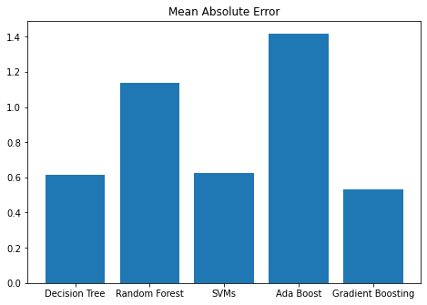

```python
fig = plt.figure()
ax = fig.add_axes([0,0,1,1])
x = ['Decision Tree', 'Random Forest', 'SVMs', 'Ada Boost', 'Gradient Boosting']
height = [decision_mae, random_mae, svc_mae, ada_mae, gradient_mae]
ax.bar(x, height)
plt.title('Mean Absolute Error')
plt.show()
```

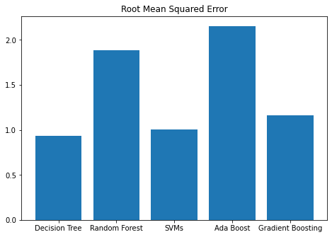

```python
fig = plt.figure()
ax = fig.add_axes([0,0,1,1])
x = ['Decision Tree', 'Random Forest', 'SVMs', 'Ada Boost', 'Gradient Boosting']
height = [decision_mse, random_mse, svc_mse, ada_mse, gradient_mse]
ax.bar(x, height)
plt.title('Root Mean Squared Error')
plt.show()
```

**Result/Conclusion from Decision Tree, SVMs(Support Vector Machines), Ada Boost, and Gradient Boosting:**

**We can conclude by saying that Decision Tree, SVMs(Support Vector Machines), and Gradient Boosting were the best models in the terms of performance.**

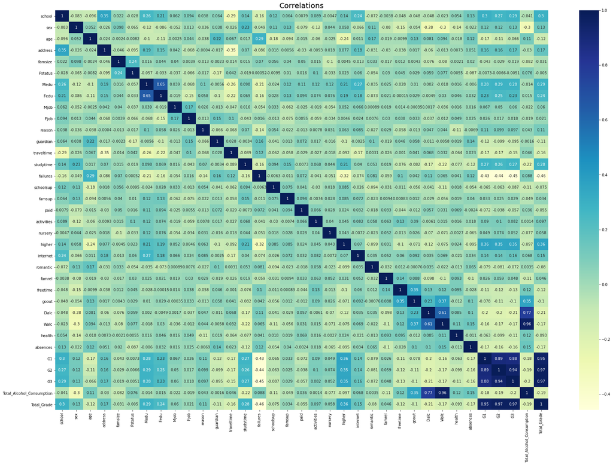

```python
fig = plt.figure(figsize = (30, 20))
sns.heatmap(studentPOR.corr(method = "spearman"), cmap="YlGnBu", annot = True)
plt.title("Correlations", size = 20)
```

### New Question

**If we notice the data values of studentPOR dataframe, some object type columns were changed in the analysis to numeric values. Now, based on the new correlation heatmap graph in the above cell, what new correlations observations can be discover ? Are there any correlation found which were not a part of the observation in previous correlation heatmap ? Are those new correlation any significant ? Make some analysis and see if there are any other attributes of the column which are more contributing towards affecting the grades or alcohol consumption of students ?**

**Some Observations from the correlation heatmap graph above:**

*1. The correlation of "school" with "Medu" and "Fedu" is moderate. "GP" students are likely to have parents with higher levels of education.*

*2. "school" have a moderate positive correlation with "G1", "G2", and "G3". It seems like students who are in the "GP" school tend to have higher grades than students in the other school.*

*3. "higher" and "age" have a moderate negative correlation(-0.24). Meaning students who wish to continue their studies are likely to be younger i.e. they have a lower age.*

*4. "higher" have a moderate positive correlation with "G1", "G2" and "G3". Meaning students who want to continue their studies tend to have higher grades.*

*6. "address" and "traveltime" have a moderate negative correlation. It seems like that those from urban areas tend to have a less time to reach school.*

*7. "higher" has a moderate correlation with "Medu", "studytime" and "failures. It can be seen that students who plan to continue their studies are more likely to have a mother with a high level of education, spend more hours studying, and with that they have lesser failures.*

*8. "medu" and "internet" have a moderate positive correlation. Meaning students who have a mother with a high level of education are likely to have internet access.*

**Note: Our aim is to find how the grades of students are being affected. One interesting observation obtained is "school" being correlated with grades of students i.e. with "G1", "G2", and "G3". On the other hand correlation with "higher" and "G1", "G2", and "G3" is more likely to happen since students who wish to study further will be little more serious towards studying than who do not wish to attend higher education to keep their grades good and preparing them for further studies.**

Let's use the boxplot as a our visulization method to find how the grades of students "G1", "G2", and "G3" changes against "school", "address", "internet".

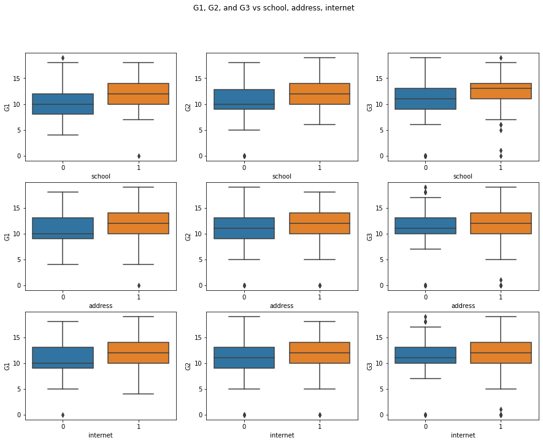

```python
fig, axes = plt.subplots(3, 3, figsize = (15, 11))

ax1 = plt.subplot(axes[0, 0])
ax1 = sns.boxplot(data = studentPOR, x = studentPOR['school'], y = studentPOR['G1'])

ax2 = plt.subplot(axes[0, 1])
ax2 = sns.boxplot(data = studentPOR, x = studentPOR['school'], y = studentPOR['G2'])

ax3 = plt.subplot(axes[0, 2])
ax3 = sns.boxplot(data = studentPOR, x = studentPOR['school'], y = studentPOR['G3'])

ax4 = plt.subplot(axes[1, 0])
ax4 = sns.boxplot(data = studentPOR, x = studentPOR['address'], y = studentPOR['G1'])

ax5 = plt.subplot(axes[1, 1])
ax5 = sns.boxplot(data = studentPOR, x = studentPOR['address'], y = studentPOR['G2'])

ax6 = plt.subplot(axes[1, 2])
ax6 = sns.boxplot(data = studentPOR, x = studentPOR['address'], y = studentPOR['G3'])

ax7 = plt.subplot(axes[2, 0])
ax7 = sns.boxplot(data = studentPOR, x = studentPOR['internet'], y = studentPOR['G1'])

ax8 = plt.subplot(axes[2, 1])
ax8 = sns.boxplot(data = studentPOR, x = studentPOR['internet'], y = studentPOR['G2'])

ax9 = plt.subplot(axes[2, 2])
ax9 = sns.boxplot(data = studentPOR, x = studentPOR['internet'], y = studentPOR['G3'])

plt.suptitle('G1, G2, and G3 vs school, address, internet')
```

From the boxplot above, we can observe that students who went to school '1' i.e. GP (or Gabriel Pereira) tend to have higher grades in all tests (G1, G2, and G3) than students who went to 'MS' (or Mousinho da Silveira). It looks like grades might be affected by the school a student chooses to attend. Moreover, the difference between grades of students vs address and internet do not depict any significant result.

Moving forward, let's see how students desire to pursue higher education influences the grades by school.

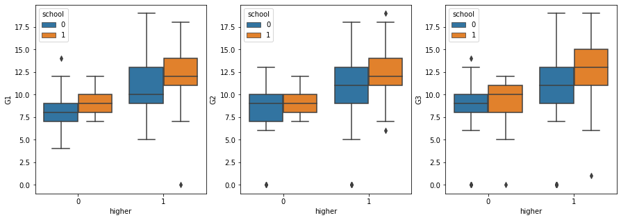

```python
fig, axes = plt.subplots(1, 3, figsize = (15, 5))

ax1 = plt.subplot(axes[0])
ax1 = sns.boxplot(data = studentPOR, x = studentPOR['higher'], y = studentPOR['G1'], hue = studentPOR['school'])

ax2 = plt.subplot(axes[1])
ax2 = sns.boxplot(data = studentPOR, x = studentPOR['higher'], y = studentPOR['G2'], hue = studentPOR['school'])

ax3 = plt.subplot(axes[2])
ax3 = sns.boxplot(data = studentPOR, x = studentPOR['higher'], y = studentPOR['G3'], hue = studentPOR['school'])
```

From the box plot visualization above we can see that students who wish to pursue higher education have a better score than those who do not wish for further studies and of those who wishes for higher education students and belong to 'GP' school have a higher score than those who wish for higher education and belong to 'MS' school.

**With the help of visualization and observations made from correlation heatmap, we certainly know that grades 'G1', 'G2', and 'G3' are being affected or influenced depending on what school ('GP' or 'MS') a student chooses. And students who attend 'GP' are likely to have a better score than 'MS' students.**

Let's see if there are any other factors affecting the grades before we begin our analysis on how school is responsible for affecting the grades of students.

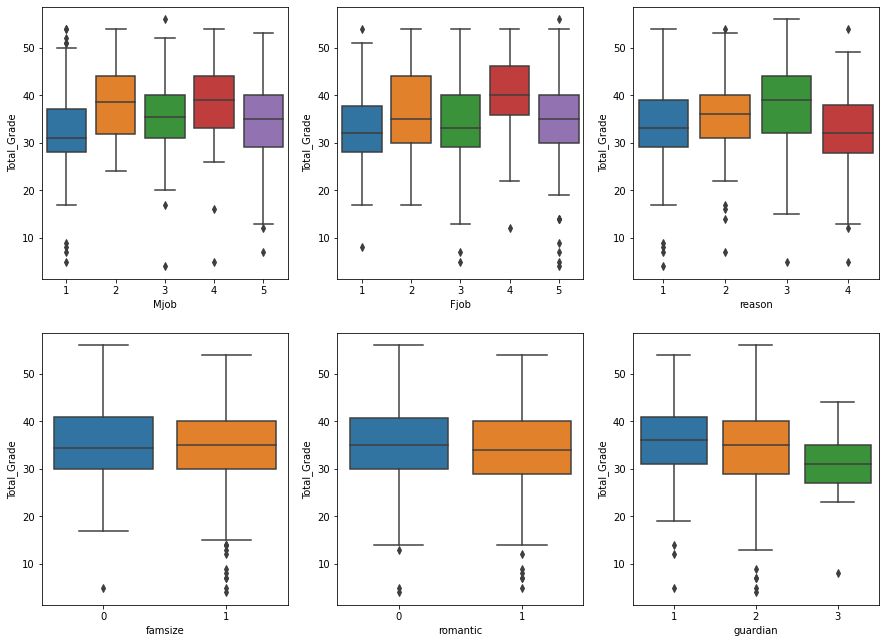

```python
fig, axes = plt.subplots(2, 3, figsize = (15, 11))

ax1 = plt.subplot(axes[0, 0])
ax1 = sns.boxplot(data = studentPOR, x = studentPOR['Mjob'], y = studentPOR['Total_Grade'])

ax2 = plt.subplot(axes[0, 1])
ax2 = sns.boxplot(data = studentPOR, x = studentPOR['Fjob'], y = studentPOR['Total_Grade'])

ax3 = plt.subplot(axes[0, 2])
ax3 = sns.boxplot(data = studentPOR, x = studentPOR['reason'], y = studentPOR['Total_Grade'])

ax4 = plt.subplot(axes[1, 0])
ax4 = sns.boxplot(data = studentPOR, x = studentPOR['famsize'], y = studentPOR['Total_Grade'])

ax5 = plt.subplot(axes[1, 1])
ax5 = sns.boxplot(data = studentPOR, x = studentPOR['romantic'], y = studentPOR['Total_Grade'])

ax6 = plt.subplot(axes[1, 2])
ax6 = sns.boxplot(data = studentPOR, x = studentPOR['guardian'], y = studentPOR['Total_Grade'])
```

*For reference:*

*Mjob - mother's job (at_home = 1, health = 2, services = 3, teacher = 4, other =5)*

*Fjob - mother's job (at_home = 1, health = 2, services = 3, teacher = 4, other =5)*

*reason - reason to choose this school (course = 1, home = 2, reputation = 3, other = 4)*

From the box plot in the above cell, student parents (mother and father) who were working in 'health' (i.e. '2') or as a 'teacher'(i.e. 4) are likely to have an overall grade better than other students whose parents were either at home, or in services, or other.

Also, it can be seen that students who choose the school for it's reputation are very likely to have higher overall grade than those who choose the school for it's course, or close to home, or some other reasons.

**Note: We already had made some observations on how student going to different school influences their grades and we can notice here as well that if the student chooses a school for it's reputation, they are likely to score better. And this helps us to understand that student's selecting a school and reason behind selecting a school plays an important role in describing student's grades. Based on these obervations, we can say that 'school' is one of the attributes in the dataframe responsible for affecting a student's grades.**

For further analysis, let's try to calculate mean and median of grades for students who goes to 'GP' and 'MS'.

```python
gp = studentPOR[studentPOR.school == 1]
print("Mean of Total_Grade of students who go to GP is", gp.Total_Grade.mean())
print("Median of Total_Grade of students who go to GP is", gp.Total_Grade.median())
```

```
Mean of Total_Grade of students who go to GP is 36.70685579196218
Median of Total_Grade of students who go to GP is 37.0
```

```python
ms = studentPOR[studentPOR.school == 0]
print("Mean of Total_Grade of students who go to MS is", ms.Total_Grade.mean())
print("Median of Total_Grade of students who go to MS is", ms.Total_Grade.median())
```

```
Mean of Total_Grade of students who go to MS is 31.446902654867255
Median of Total_Grade of students who go to MS is 30.0
```

**We can certainly conclude that students have a better average grades and higher median when they choose 'GP' as their school over 'MS'.**

**Both the dataset 'student-mat.csv' (dataset of student taking math course) and 'student-por.csv' (dataset of student taking portugese language course) have 370 students that belong to both the datasets. These 370 students are identified by searching for identical attributes that characterizes each student. And these 370 students were merged into a dataframe named 'mergeDF' which will be used for the part of analyzing.**

```python
studentMAT = pd.read_csv("student-mat.csv")
studentPOR = pd.read_csv("student-por.csv")
mergeDF = pd.merge(studentMAT, studentPOR, how='inner', on= ['school', 'sex','age','address',
        'famsize', 'Pstatus', 'Medu', 'Fedu', 'Mjob', 'Fjob', 'reason',
        'guardian', 'schoolsup', 'famsup', 'activities', 'nursery',
        'higher', 'internet', 'romantic', 'famrel'])
pd.set_option('display.max_columns', None)
print("Total students appearing in both Portugese and Math Course:", len(mergeDF.index))
print("Shape of mergeDF:", mergeDF.shape)
mergeDF.head()
```

```
Total students appearing in both Portugese and Math Course: 370
Shape of mergeDF: (370, 46)
```

|  | school | sex | age | address | famsize | Pstatus | Medu | Fedu | Mjob | Fjob | reason | guardian | traveltime_x | studytime_x | failures_x | schoolsup | famsup | paid_x | activities | nursery | higher | internet | romantic | famrel | freetime_x | goout_x | Dalc_x | Walc_x | health_x | … |
| --- | --- | --- | --- | --- | --- | --- | --- | --- | --- | --- | --- | --- | --- | --- | --- | --- | --- | --- | --- | --- | --- | --- | --- | --- | --- | --- | --- | --- | --- | --- |
| 0 | GP | F | 18 | U | GT3 | A | 4 | 4 | at_home | teacher | course | mother | 2 | 2 | 0 | yes | no | no | no | yes | yes | no | no | 4 | 3 | 4 | 1 | 1 | 3 | … |
| 1 | GP | F | 17 | U | GT3 | T | 1 | 1 | at_home | other | course | father | 1 | 2 | 0 | no | yes | no | no | no | yes | yes | no | 5 | 3 | 3 | 1 | 1 | 3 | … |
| 2 | GP | F | 15 | U | LE3 | T | 1 | 1 | at_home | other | other | mother | 1 | 2 | 3 | yes | no | yes | no | yes | yes | yes | no | 4 | 3 | 2 | 2 | 3 | 3 | … |
| 3 | GP | F | 15 | U | GT3 | T | 4 | 2 | health | services | home | mother | 1 | 3 | 0 | no | yes | yes | yes | yes | yes | yes | yes | 3 | 2 | 2 | 1 | 1 | 5 | … |
| 4 | GP | F | 16 | U | GT3 | T | 3 | 3 | other | other | home | father | 1 | 2 | 0 | no | yes | yes | no | yes | yes | no | no | 4 | 3 | 2 | 1 | 2 | 5 | … |

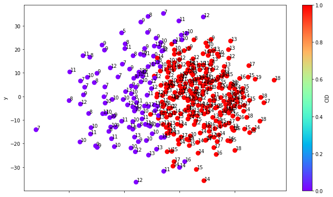

```python
import pandas as pd
import sklearn.cluster as cl
import sklearn.metrics.pairwise as pairs

quantDF = mergeDF.drop(['school','address','sex','famsize','Pstatus','Mjob','Fjob','reason','guardian','schoolsup','famsup','paid_x','activities','nursery','higher','internet','romantic','paid_y'], axis=1)
normDF = (quantDF - quantDF.mean()) / quantDF.std()
km = cl.KMeans(n_clusters = 2)
labels = km.fit_predict(normDF)
normDF['CID'] = labels
normHD = pairs.manhattan_distances(normDF.iloc[:, :-1])
normHD = pd.DataFrame(normHD, columns=normDF.index, index=normDF.index)
import sklearn.manifold as mani
mds = mani.MDS(dissimilarity='precomputed')
data2D = mds.fit_transform(normHD)
data2D = pd.DataFrame(data2D, index=normHD.index, columns=['x','y'])
data2D['CID'] = normDF.CID
ax = data2D.plot.scatter(x='x', y='y', c='CID',  s=75, cmap='rainbow', figsize=(12,7))
for i in range(len(data2D)):
    ax.text(data2D.x[i]+0.2, data2D.y[i]+0.2, mergeDF.G1_y[i])
```

**Question: Can we predict gender of student based on alcohol consumption, study time, failures, family relations, freetime, how much they go out, Dalc, Walc, health, absences, and G3 for the studentMAT and studentPOR datasets?**

```python
x1 = pd.DataFrame(studentMAT[['failures','Dalc','Walc','absences','famrel','freetime',
                         'goout','G3','health','studytime','traveltime']])
y1 = pd.DataFrame(studentMAT['sex'])
```

```python
(x1_train, x1_test, y1_train, y1_test) = train_test_split(x1, y1, test_size=0.2)
classifier = DecisionTreeClassifier()
classifier.fit(x1_train,y1_train)
y1_pred = classifier.predict(x1_test)
print(confusion_matrix(y1_test, y1_pred))
print(classification_report(y1_test, y1_pred))
```

```
[[21 25]
 [13 20]]
              precision    recall  f1-score   support

           F       0.62      0.46      0.52        46
           M       0.44      0.61      0.51        33

    accuracy                           0.52        79
   macro avg       0.53      0.53      0.52        79
weighted avg       0.55      0.52      0.52        79
```

Now we will construct a decision tree to predict gender with the same quantitative factors but we will use the dataset with students taking the portugese class.

```python
x2 = pd.DataFrame(studentPOR[['failures','Dalc','Walc','absences','famrel','freetime',
                         'goout','G3','health','studytime','traveltime']])
y2 = pd.DataFrame(studentPOR['sex'])
```

```python
(x2_train, x2_test, y2_train, y2_test) = train_test_split(x2, y2, test_size=0.2)
classifier = DecisionTreeClassifier()
classifier.fit(x2_train,y2_train)
y2_pred = classifier.predict(x2_test)
print(confusion_matrix(y2_test, y2_pred))
print(classification_report(y2_test, y2_pred))
```

```
[[47 26]
 [29 28]]
              precision    recall  f1-score   support

           F       0.62      0.64      0.63        73
           M       0.52      0.49      0.50        57

    accuracy                           0.58       130
   macro avg       0.57      0.57      0.57       130
weighted avg       0.57      0.58      0.58       130
```

After trying the decision tree for the portugal dataset our esults are very similar. Regardless of the subject being portugal or math, students' gender doesn't have a very strong affect on factors such as overall grade, amount of time they spend studying, amount of time they spend going out.

**Now based on the result we found that 'school' is one of the factor affecting student's grades, we can try to predict whether a student goes to Mousinho da Silveira or Gabriel Pereira based on quantitative factors such as alcohol consumption, study time, failors, family relations, freetime, how much they go out, Dalc, Walc, health, absences, and G3 for the studentMAT and studentPOR.**

```python
x3 = pd.DataFrame(studentMAT[['failures','Dalc','Walc','absences','famrel','freetime',
                         'goout','G3','health','studytime','traveltime']])
y3 = pd.DataFrame(studentMAT['school'])
```

```python
# Decision Tree for School vs other factors
(x3_train, x3_test, y3_train, y3_test) = train_test_split(x3, y3, test_size=0.2)
classifier = DecisionTreeClassifier()
classifier.fit(x3_train,y3_train)
y3_pred = classifier.predict(x3_test)
print(confusion_matrix(y3_test, y3_pred))
print(classification_report(y3_test, y3_pred))
```

```
[[65  4]
 [ 6  4]]
              precision    recall  f1-score   support

          GP       0.92      0.94      0.93        69
          MS       0.50      0.40      0.44        10

    accuracy                           0.87        79
   macro avg       0.71      0.67      0.69        79
weighted avg       0.86      0.87      0.87        79
```

We can see that for students from GP our decison tree alogrithm did quite well as the majority of our dataset consists of students from GP. While we only have a sample of 10 students from MS it is hard to gain accuracy. The reason we got high precision, recall, and f1 scores for students who went to GP is affected by the fact that the sample consists of the vast majority of students who went to GP.

```python
x4 = pd.DataFrame(studentPOR[['failures','Dalc','Walc','absences','famrel','freetime',
                         'goout','G3','health','studytime','traveltime']])
#GP = 1, MS = 0
y4 = pd.DataFrame(studentPOR['school'])
```

```python
(x4_train, x4_test, y4_train, y4_test) = train_test_split(x4, y4, test_size=0.2)
classifier = DecisionTreeClassifier()
classifier.fit(x4_train,y4_train)
y4_pred = classifier.predict(x4_test)
print(confusion_matrix(y4_test, y4_pred))
print(classification_report(y4_test, y4_pred))
```

```
[[74 24]
 [16 16]]
              precision    recall  f1-score   support

          GP       0.82      0.76      0.79        98
          MS       0.40      0.50      0.44        32

    accuracy                           0.69       130
   macro avg       0.61      0.63      0.62       130
weighted avg       0.72      0.69      0.70       130
```

**Final Conclusion: Based on our dataset studentPOR mainly, we can finally conclude that 'school' and 'Total_Alcohol_Consumption' were the factors responsible for affecting the grades of students and in order to achieve better grades, students can make better decision deciding which school he/she/they want to attend and on top of that they can start by reducing the alcohol consumption level on weekend and it will eventually lessen the alcohol consumption for weekdays.**